# USOLFC project

## USA-Office of Foreign Labor Certification (OFLC) Project

## Problem Statement

### Context:

Business communities in the United States are facing high demand for human resources, but one of the constant challenges is identifying and attracting the right talent, which is perhaps the most important element in remaining competitive. Companies in the United States look for hard-working, talented, and qualified individuals both locally as well as abroad.

The Immigration and Nationality Act (INA) of the US permits foreign workers to come to the United States to work on either a temporary or permanent basis. The act also protects US workers against adverse impacts on their wages or working conditions by ensuring US employers' compliance with statutory requirements when they hire foreign workers to fill workforce shortages. The immigration programs are administered by the Office of Foreign Labor Certification (OFLC).

OFLC processes job certification applications for employers seeking to bring foreign workers into the United States and grants certifications in those cases where employers can demonstrate that there are not sufficient US workers available to perform the work at wages that meet or exceed the wage paid for the occupation in the area of intended employment.

### Objective:

In FY 2016, the OFLC processed 775,979 employer applications for 1,699,957 positions for temporary and permanent labor certifications. This was a nine percent increase in the overall number of processed applications from the previous year. The process of reviewing every case is becoming a tedious task as the number of applicants is increasing every year.

The increasing number of applicants every year calls for a Machine Learning based solution that can help in shortlisting the candidates having higher chances of VISA approval. OFLC has hired the firm EasyVisa for data-driven solutions. You as a data scientist at EasyVisa have to analyze the data provided and, with the help of a classification model:

- Facilitate the process of visa approvals.
- Recommend a suitable profile for the applicants for whom the visa should be certified or denied based on the drivers that significantly influence the case status.

### Data Description

The data contains the different attributes of employee and the employer. The detailed data dictionary is given below.

- case_id: ID of each visa application
- continent: Information of continent the employee
- education_of_employee: Information of education of the employee
- has_job_experience: Does the employee has any job experience? Y= Yes; N = No
- requires_job_training: Does the employee require any job training? Y = Yes; N = No
- no_of_employees: Number of employees in the employer's company
- yr_of_estab: Year in which the employer's company was established
- region_of_employment: Information of foreign worker's intended region of employment in the US.
- prevailing_wage: Average wage paid to similarly employed workers in a specific occupation in the area of intended employment. The purpose of the prevailing wage is to ensure that the foreign worker is not underpaid compared to other workers offering the same or similar service in the same area of employment.
- unit_of_wage: Unit of prevailing wage. Values include Hourly, Weekly, Monthly, and Yearly.
- full_time_position: Is the position of work full-time? Y = Full Time Position; N = Part Time Position
- case_status: Flag indicating if the Visa was certified or denied

## Importing necessary libraries

```python
import warnings

warnings.filterwarnings("ignore")

import numpy as np
import pandas as pd

from sklearn.model_selection import train_test_split

import matplotlib.pyplot as plt
import seaborn as sns

pd.set_option("display.max_columns", None)
pd.set_option("display.max_rows", 100)


from sklearn.ensemble import (
    BaggingClassifier,
    RandomForestClassifier,
    AdaBoostClassifier,
    GradientBoostingClassifier,
    StackingClassifier,
)

from xgboost import XGBClassifier
from sklearn.tree import DecisionTreeClassifier

from sklearn import metrics
from sklearn.metrics import (
    confusion_matrix,
    accuracy_score,
    precision_score,
    recall_score,
    f1_score,
)

from sklearn.model_selection import GridSearchCV
```

## Importing Dataset

```python
visa = pd.read_csv("Downloads/Easyvisa.csv")  ##  Fill the blank to read the data
```

```python
data = visa.copy()
```

## Overview of the Dataset

### View the first and last 5 rows of the dataset

```python
data.head(5)
```

|  | case_id | continent | education_of_employee | has_job_experience | requires_job_training | no_of_employees | yr_of_estab | region_of_employment | prevailing_wage | unit_of_wage | full_time_position | case_status |
| --- | --- | --- | --- | --- | --- | --- | --- | --- | --- | --- | --- | --- |
| 0 | EZYV01 | Asia | High School | N | N | 14513 | 2007 | West | 592.2029 | Hour | Y | Denied |
| 1 | EZYV02 | Asia | Master's | Y | N | 2412 | 2002 | Northeast | 83425.6500 | Year | Y | Certified |
| 2 | EZYV03 | Asia | Bachelor's | N | Y | 44444 | 2008 | West | 122996.8600 | Year | Y | Denied |
| 3 | EZYV04 | Asia | Bachelor's | N | N | 98 | 1897 | West | 83434.0300 | Year | Y | Denied |
| 4 | EZYV05 | Africa | Master's | Y | N | 1082 | 2005 | South | 149907.3900 | Year | Y | Certified |

```python
data.tail(5)
```

|  | case_id | continent | education_of_employee | has_job_experience | requires_job_training | no_of_employees | yr_of_estab | region_of_employment | prevailing_wage | unit_of_wage | full_time_position | case_status |
| --- | --- | --- | --- | --- | --- | --- | --- | --- | --- | --- | --- | --- |
| 25475 | EZYV25476 | Asia | Bachelor's | Y | Y | 2601 | 2008 | South | 77092.57 | Year | Y | Certified |
| 25476 | EZYV25477 | Asia | High School | Y | N | 3274 | 2006 | Northeast | 279174.79 | Year | Y | Certified |
| 25477 | EZYV25478 | Asia | Master's | Y | N | 1121 | 1910 | South | 146298.85 | Year | N | Certified |
| 25478 | EZYV25479 | Asia | Master's | Y | Y | 1918 | 1887 | West | 86154.77 | Year | Y | Certified |
| 25479 | EZYV25480 | Asia | Bachelor's | Y | N | 3195 | 1960 | Midwest | 70876.91 | Year | Y | Certified |

### Understand the shape of the dataset

```python
data.shape
```

```
(25480, 12)
```

- The data set has 25480 rows and columns

### Check the data types of the columns for the dataset

```python
data.info()
```

```
<class 'pandas.core.frame.DataFrame'>
RangeIndex: 25480 entries, 0 to 25479
Data columns (total 12 columns):
 #   Column                 Non-Null Count  Dtype
---  ------                 --------------  -----
 0   case_id                25480 non-null  object
 1   continent              25480 non-null  object
 2   education_of_employee  25480 non-null  object
 3   has_job_experience     25480 non-null  object
 4   requires_job_training  25480 non-null  object
 5   no_of_employees        25480 non-null  int64
 6   yr_of_estab            25480 non-null  int64
 7   region_of_employment   25480 non-null  object
 8   prevailing_wage        25480 non-null  float64
 9   unit_of_wage           25480 non-null  object
 10  full_time_position     25480 non-null  object
 11  case_status            25480 non-null  object
dtypes: float64(1), int64(2), object(9)
memory usage: 2.3+ MB
```

- no of employees, year of establishment, and prevailing wage are nummeric features while rest are objects.
- There is no null-values in the data set

```python
data.duplicated().sum()
```

```
0
```

```python
data.isna().sum()
```

```
case_id                  0
continent                0
education_of_employee    0
has_job_experience       0
requires_job_training    0
no_of_employees          0
yr_of_estab              0
region_of_employment     0
prevailing_wage          0
unit_of_wage             0
full_time_position       0
case_status              0
dtype: int64
```

- There are no duplicate values in the data

## Exploratory Data Analysis

#### Let's check the statistical summary of the data

```python
data.describe().T
```

|  | count | mean | std | min | 25% | 50% | 75% | max |
| --- | --- | --- | --- | --- | --- | --- | --- | --- |
| no_of_employees | 25480.0 | 5667.043210 | 22877.928848 | -26.0000 | 1022.00 | 2109.00 | 3504.0000 | 602069.00 |
| yr_of_estab | 25480.0 | 1979.409929 | 42.366929 | 1800.0000 | 1976.00 | 1997.00 | 2005.0000 | 2016.00 |
| prevailing_wage | 25480.0 | 74455.814592 | 52815.942327 | 2.1367 | 34015.48 | 70308.21 | 107735.5125 | 319210.27 |

- The number of emplyee have a negative value; likely an anomaly.
- Year of employee is betweeen 1800 - 2016
- The median prevailing wage is 70,308. There is a huge differnfe between maximum value and the 75th percentile; likely an outlier in this column

#### Fixing the negative values in number of employees columns

```python
data.loc[data["no_of_employees"] < 0].shape
```

```
(33, 12)
```

```python
data["no_of_employees"] = abs(data["no_of_employees"])
```

- Changing the 33 negative observations as data entry errors and taking the absolute values for this column.

#### Let's check the count of each unique category in each of the categorical variables

```python
cat_col = list(data.select_dtypes("object").columns)
for column in cat_col:
    print(data[column].value_counts())
    print("-" * 50)
```

```
EZYV01       1
EZYV16995    1
EZYV16993    1
EZYV16992    1
EZYV16991    1
            ..
EZYV8492     1
EZYV8491     1
EZYV8490     1
EZYV8489     1
EZYV25480    1
Name: case_id, Length: 25480, dtype: int64
--------------------------------------------------
Asia             16861
Europe            3732
North America     3292
South America      852
Africa             551
Oceania            192
Name: continent, dtype: int64
--------------------------------------------------
Bachelor's     10234
Master's        9634
High School     3420
Doctorate       2192
Name: education_of_employee, dtype: int64
--------------------------------------------------
Y    14802
N    10678
Name: has_job_experience, dtype: int64
--------------------------------------------------
N    22525
Y     2955
Name: requires_job_training, dtype: int64
--------------------------------------------------
Northeast    7195
South        7017
West         6586
Midwest      4307
Island        375
Name: region_of_employment, dtype: int64
--------------------------------------------------
Year     22962
Hour      2157
Week       272
Month       89
Name: unit_of_wage, dtype: int64
--------------------------------------------------
Y    22773
N     2707
Name: full_time_position, dtype: int64
--------------------------------------------------
Certified    17018
Denied        8462
Name: case_status, dtype: int64
--------------------------------------------------
```

- I cahnged the list of all categorical variables to object to get details information from the data sets.
- Asians have the highest number of job applications.
- Most of the application have a bachelors degree.
- Most applicants have job experience and do not recquire training.
- The Northe-East region has the highest number of location for apllicant.
- Most of the visa application are for full time job postions
- The target column "case status" is imbalance with many applicantnhaving a certifes visa

```python
data["case_id"].nunique()
```

```
25480
```

```python
data.drop(
    ["case_id"], axis=1, inplace=True)
```

- Dropping the "case-id" column because they are unigue and are not significant in the data set

### Univariate Analysis

```python
def histogram_boxplot(data, feature, figsize=(15, 10), kde=False, bins=None):
    """
    Boxplot and histogram combined

    data: dataframe
    feature: dataframe column
    figsize: size of figure (default (15,10))
    kde: whether to show the density curve (default False)
    bins: number of bins for histogram (default None)
    """
    f2, (ax_box2, ax_hist2) = plt.subplots(
        nrows=2,
        sharex=True,
        gridspec_kw={"height_ratios": (0.25, 0.75)},
        figsize=figsize,
    )
    sns.boxplot(
        data=data, x=feature, ax=ax_box2, showmeans=True, color="violet"
    )
    sns.histplot(
        data=data, x=feature, kde=kde, ax=ax_hist2, bins=bins
    ) if bins else sns.histplot(
        data=data, x=feature, kde=kde, ax=ax_hist2
    )
    ax_hist2.axvline(
        data[feature].mean(), color="green", linestyle="--"
    )
    ax_hist2.axvline(
        data[feature].median(), color="black", linestyle="-"
    )
```

#### Observations on number of employees

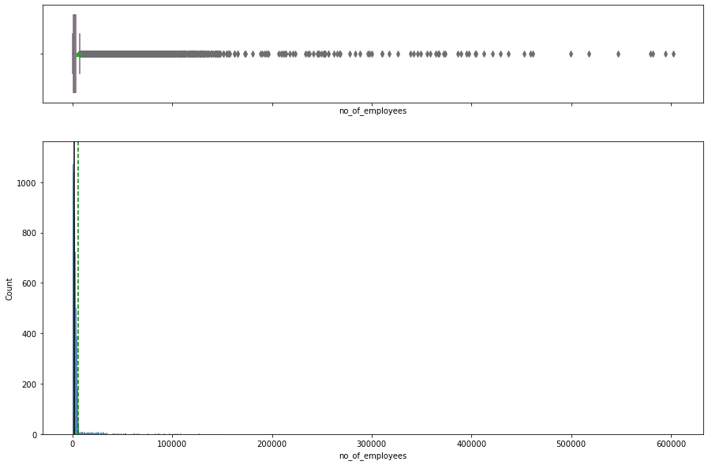

```python
histogram_boxplot(data, "no_of_employees")
```

- The number of employees distribution is right skewed.
- Some comoaniees have more than 500, 000 number of employees, probably international companies.

#### Observations on prevailing wage

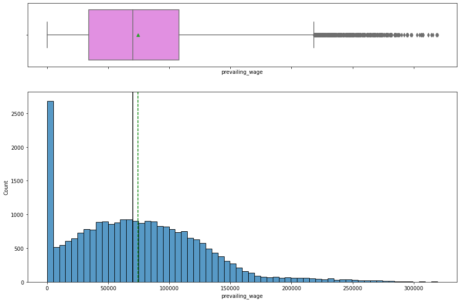

```python
histogram_boxplot(data, "prevailing_wage")
```

```python
data.loc[data["prevailing_wage"] < 100, "unit_of_wage"].shape
```

```
(176,)
```

```python
data.loc[data["prevailing_wage"] < 100]
```

|  | continent | education_of_employee | has_job_experience | requires_job_training | no_of_employees | yr_of_estab | region_of_employment | prevailing_wage | unit_of_wage | full_time_position | case_status |
| --- | --- | --- | --- | --- | --- | --- | --- | --- | --- | --- | --- |
| 338 | Asia | Bachelor's | Y | N | 2114 | 2012 | Northeast | 15.7716 | Hour | Y | Certified |
| 634 | Asia | Master's | N | N | 834 | 1977 | Northeast | 3.3188 | Hour | Y | Denied |
| 839 | Asia | High School | Y | N | 4537 | 1999 | West | 61.1329 | Hour | Y | Denied |
| 876 | South America | Bachelor's | Y | N | 731 | 2004 | Northeast | 82.0029 | Hour | Y | Denied |
| 995 | Asia | Master's | N | N | 302 | 2000 | South | 47.4872 | Hour | Y | Certified |
| ... | ... | ... | ... | ... | ... | ... | ... | ... | ... | ... | ... |
| 25023 | Asia | Bachelor's | N | Y | 3200 | 1994 | South | 94.1546 | Hour | Y | Denied |
| 25258 | Asia | Bachelor's | Y | N | 3659 | 1997 | South | 79.1099 | Hour | Y | Denied |
| 25308 | North America | Master's | N | N | 82953 | 1977 | Northeast | 42.7705 | Hour | Y | Denied |
| 25329 | Africa | Bachelor's | N | N | 2172 | 1993 | Northeast | 32.9286 | Hour | Y | Denied |
| 25461 | Asia | Master's | Y | N | 2861 | 2004 | West | 54.9196 | Hour | Y | Denied |

176 rows × 11 columns

### Categorical Varibale EDA

```python
def labeled_barplot(data, feature, perc=False, n=None):
    """
    Barplot with percentage at the top

    data: dataframe
    feature: dataframe column
    perc: whether to display percentages instead of count (default is False)
    n: displays the top n category levels (default is None, i.e., display all levels)
    """

    total = len(data[feature])
    count = data[feature].nunique()
    if n is None:
        plt.figure(figsize=(count + 2, 6))
    else:
        plt.figure(figsize=(n + 2, 6))

    plt.xticks(rotation=90, fontsize=15)
    ax = sns.countplot(
        data=data,
        x=feature,
        palette="Paired",
        order=data[feature].value_counts().index[:n],
    )

    for p in ax.patches:
        if perc == True:
            label = "{:.1f}%".format(
                100 * p.get_height() / total
            )
        else:
            label = p.get_height()

        x = p.get_x() + p.get_width() / 2
        y = p.get_height()

        ax.annotate(
            label,
            (x, y),
            ha="center",
            va="center",
            size=12,
            xytext=(0, 5),
            textcoords="offset points",
        )

    plt.show()
```

#### Observations on continent

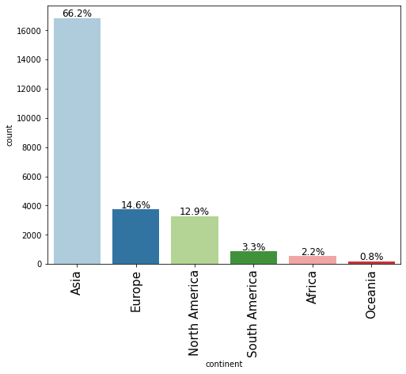

```python
labeled_barplot(data, "continent", perc=True)
```

- The highest applicant are from Asia, lowest from Oceania

#### Observations on education of employee

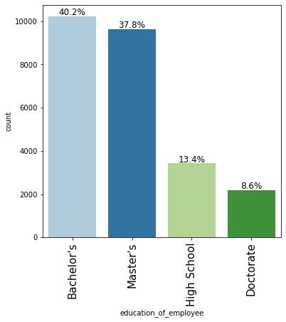

```python
labeled_barplot(data, "education_of_employee", perc=True)
```

#### Observations on job experience

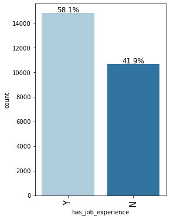

```python
labeled_barplot(data, "has_job_experience", perc=True)
```

- Most applicant have job experience prior to visa application

#### Observations on job training

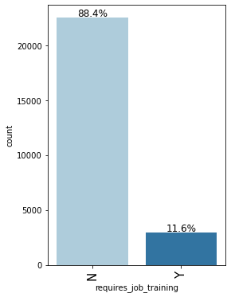

```python
labeled_barplot(data, "requires_job_training", perc=True)
```

- 88.4% of the applicant do not require training.

#### Observations on region of employment

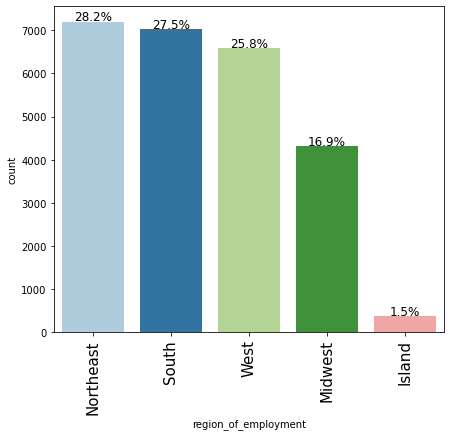

```python
labeled_barplot(data, "region_of_employment", perc=True)
```

- North-East, South and West rrgion have highest nimber of applicants
- The Island with the lowest

#### Observations on unit of wage

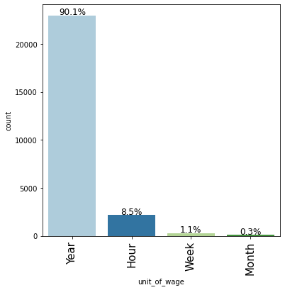

```python
labeled_barplot(data, "unit_of_wage", perc=True)
```

- 90.1% of the applicant have a yearly unit of the wag, folllw by Hour, Week, and Month.

#### Observations on case status

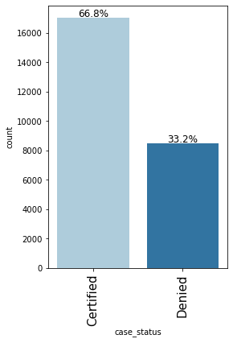

```python
labeled_barplot(data, "case_status", perc=True)
```

- 66.8% of the visas were certified.

```python
from pandas_profiling import ProfileReport

prof = ProfileReport(data)
prof
```

[interactive chart not shown]

### Bivariate Analysis

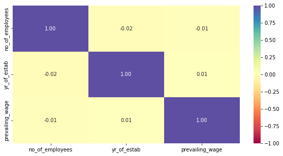

```python
cols_list = data.select_dtypes(include=np.number).columns.tolist()

plt.figure(figsize=(10, 5))
sns.heatmap(data[cols_list].corr(), annot=True, vmin=-1, vmax=1, fmt=".2f", cmap="Spectral")
plt.show()
```

- There's little to no correlation within the independent features of the data.

**Further Analysis.**

```python
def distribution_plot_wrt_target(data, predictor, target):

    fig, axs = plt.subplots(2, 2, figsize=(12, 10))

    target_uniq = data[target].unique()

    axs[0, 0].set_title("Distribution of target for target=" + str(target_uniq[0]))
    sns.histplot(
        data=data[data[target] == target_uniq[0]],
        x=predictor,
        kde=True,
        ax=axs[0, 0],
        color="teal",
        stat="density",
    )

    axs[0, 1].set_title("Distribution of target for target=" + str(target_uniq[1]))
    sns.histplot(
        data=data[data[target] == target_uniq[1]],
        x=predictor,
        kde=True,
        ax=axs[0, 1],
        color="orange",
        stat="density",
    )

    axs[1, 0].set_title("Boxplot w.r.t target")
    sns.boxplot(data=data, x=target, y=predictor, ax=axs[1, 0], palette="gist_rainbow")

    axs[1, 1].set_title("Boxplot (without outliers) w.r.t target")
    sns.boxplot(
        data=data,
        x=target,
        y=predictor,
        ax=axs[1, 1],
        showfliers=False,
        palette="gist_rainbow",
    )

    plt.tight_layout()
    plt.show()
```

```python
def stacked_barplot(data, predictor, target):
    """
    Print the category counts and plot a stacked bar chart

    data: dataframe
    predictor: independent variable
    target: target variable
    """
    count = data[predictor].nunique()
    sorter = data[target].value_counts().index[-1]
    tab1 = pd.crosstab(data[predictor], data[target], margins=True).sort_values(
        by=sorter, ascending=False
    )
    print(tab1)
    print("-" * 120)
    tab = pd.crosstab(data[predictor], data[target], normalize="index").sort_values(
        by=sorter, ascending=False
    )
    tab.plot(kind="bar", stacked=True, figsize=(count + 5, 5))
    plt.legend(
        loc="lower left", frameon=False,
    )
    plt.legend(loc="upper left", bbox_to_anchor=(1, 1))
    plt.show()
```

- Do level of education have any impact on visa certification?

```
case_status            Certified  Denied    All
education_of_employee
All                        17018    8462  25480
Bachelor's                  6367    3867  10234
High School                 1164    2256   3420
Master's                    7575    2059   9634
Doctorate                   1912     280   2192
------------------------------------------------------------------------------------------------------------------------
```

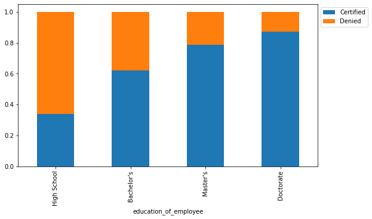

```python
stacked_barplot(data, "education_of_employee", "case_status")
```

- Education seems to have a positive relationship with the certification of visa that is higher the education higher are the chances of visa getting certified.
- Around 85% of the visa applications got certified for the applicants with Doctorate degree. While 80% of the visa applications got certified for the applicants with Master's degree.
- Around 60% of the visa applications got certified for applicants with Bachelor's degrees.
- Applicants who do not have a degree and have graduated from high school are more likely to have their applications denied.

#### Are there regional requirements for talent in diverse educational backgrounds?

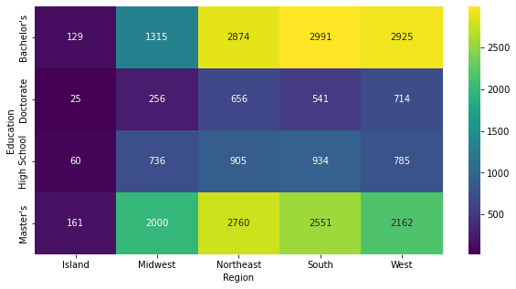

```python
plt.figure(figsize=(10, 5))
sns.heatmap(pd.crosstab(data.education_of_employee, data.region_of_employment),
    annot=True,
    fmt="g",
    cmap="viridis")

plt.ylabel("Education")
plt.xlabel("Region")
plt.show()
```

- The requirement for the applicants who have passed high school is most in the South region, followed by Northeast region.
- The requirement for Bachelor's is mostly in South region, followed by West region.
- The requirement for Master's is most in Northeast region, followed by South region.
- The requirement for Doctorate's is mostly in West region, followed by Northeast region.

#### Percentage of visa certifications across each region

```
case_status           Certified  Denied    All
region_of_employment
All                       17018    8462  25480
Northeast                  4526    2669   7195
West                       4100    2486   6586
South                      4913    2104   7017
Midwest                    3253    1054   4307
Island                      226     149    375
------------------------------------------------------------------------------------------------------------------------
```

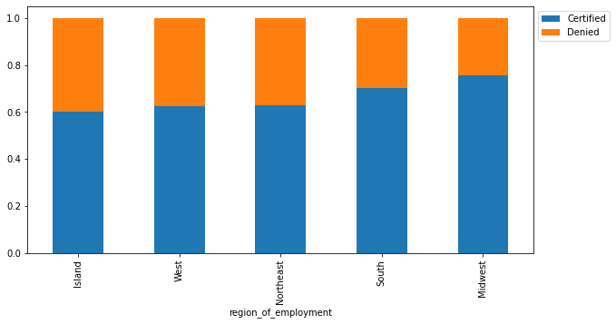

```python
stacked_barplot(data, "region_of_employment", "case_status")
```

- Midwest region sees the highest number of visa certifications - around 75%, followed by the south region that sees around 70% of the visa applications getting certified.
- Island, West, and Northeast region has an almost equal percentage of visa certifications.

#### Visa status vary across different continents.

```
case_status    Certified  Denied    All
continent
All                17018    8462  25480
Asia               11012    5849  16861
North America       2037    1255   3292
Europe              2957     775   3732
South America        493     359    852
Africa               397     154    551
Oceania              122      70    192
------------------------------------------------------------------------------------------------------------------------
```

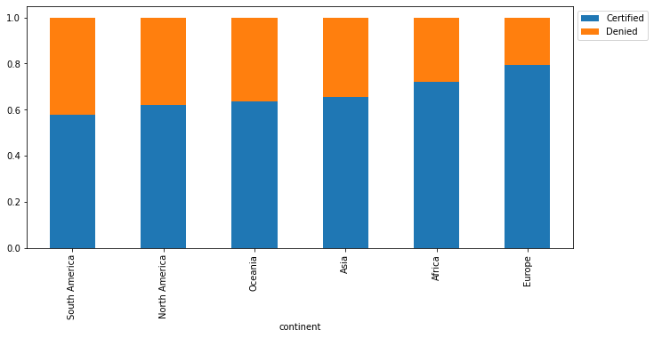

```python
stacked_barplot(data, "continent", "case_status")
```

- Applications from Europe and Africa have a higher chance of getting certified.
- Around 80% of the applications from Europe are certified.
- Asia has the third-highest percentage (Around 60%) of visa certification and has the highest number of applications.

#### Experienced professionals across visa appplication and case status.

```
case_status         Certified  Denied    All
has_job_experience
All                     17018    8462  25480
N                        5994    4684  10678
Y                       11024    3778  14802
------------------------------------------------------------------------------------------------------------------------
```

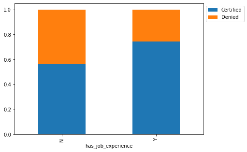

```python
stacked_barplot(data, "has_job_experience", "case_status")
```

#### Do the employees who have prior work experience require any job training?

```
requires_job_training      N     Y    All
has_job_experience
All                    22525  2955  25480
N                       8988  1690  10678
Y                      13537  1265  14802
------------------------------------------------------------------------------------------------------------------------
```

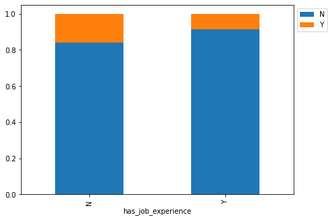

```python
stacked_barplot(data, "has_job_experience", "requires_job_training")
```

- Less percentage of applicants require job training if they have prior work experience.

#### "Prevailing wage" across "case status"

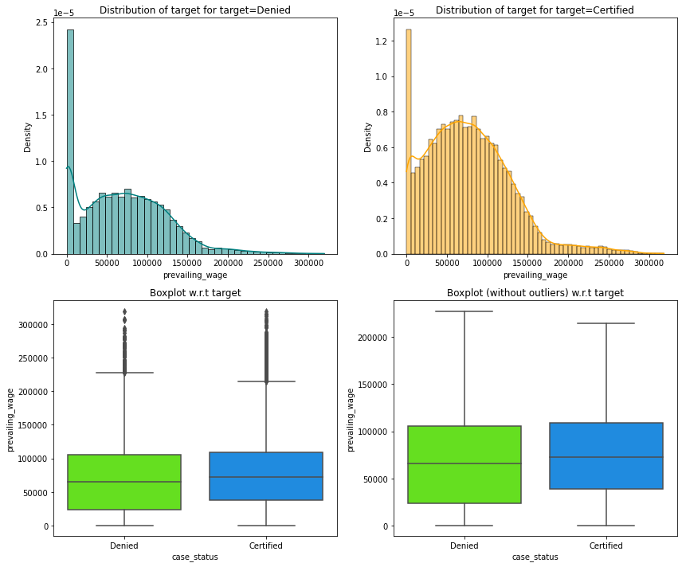

```python
distribution_plot_wrt_target(data, "prevailing_wage", "case_status")
```

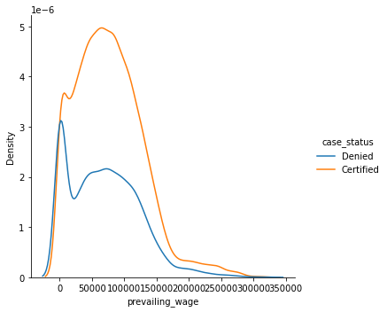

```python
sns.displot(data, x="prevailing_wage", hue="case_status", kind="kde")
```

- The median prevailing wage for the certified applications is slightly higher as compared to denied applications.

#### Checking if the prevailing wage is similar across all the regions of the US

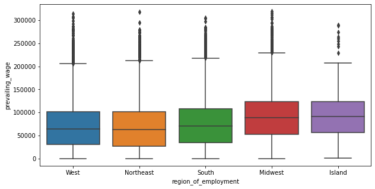

```python
plt.figure(figsize=(10, 5))
sns.boxplot(
    data=data, x="region_of_employment", y="prevailing_wage"
)  ## Complete the code to create boxplot for region of employment and prevailing wage
plt.show()
```

- Midwest and Island regions have slightly higher prevailing wages as compared to other regions.
- The distribution of prevailing wage is similar across West, Northeast, and South regions.

#### The prevailing wage has different units (Hourly, Weekly, etc). Let's find out if it has any impact on visa applications getting certified.

```
case_status   Certified  Denied    All
unit_of_wage
All               17018    8462  25480
Year              16047    6915  22962
Hour                747    1410   2157
Week                169     103    272
Month                55      34     89
------------------------------------------------------------------------------------------------------------------------
```

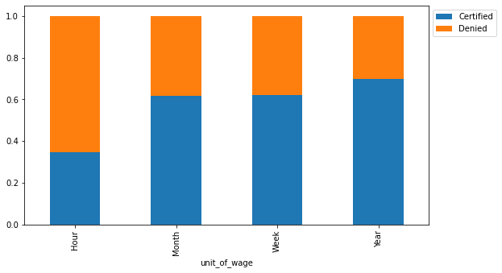

```python
stacked_barplot(data, "unit_of_wage", "case_status")
```

## Data Preprocessing

### Outlier Check

- Let's check for outliers in the data.

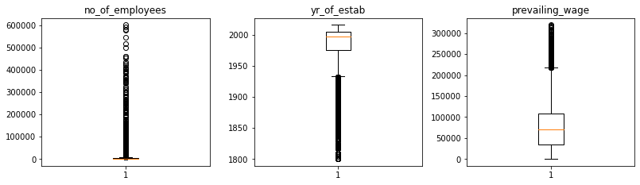

```python
numeric_columns = data.select_dtypes(include=np.number).columns.tolist()

plt.figure(figsize=(15, 12))

for i, variable in enumerate(numeric_columns):
    plt.subplot(4, 4, i + 1)
    plt.boxplot(data[variable], whis=1.5)
    plt.tight_layout()
    plt.title(variable)

plt.show()
```

- There are quite a few outliers in the data.

### Data Preparation for modeling - predicting which visa will be certified.

```python
data["case_status"] = data["case_status"].apply(lambda x: 1 if x == "Certified" else 0)

X = data.drop(["case_status"], axis=1)
Y = data["case_status"]

X = pd.get_dummies(X, drop_first=True)

X_train, X_test, y_train, y_test = train_test_split(
    X, Y, test_size=0.3, random_state=1)
```

```python
print("Shape of Training set : ", X_train.shape)
print("Shape of test set : ", X_test.shape)
print("Percentage of classes in training set:")
print(y_train.value_counts(normalize=True))
print("Percentage of classes in test set:")
print(y_test.value_counts(normalize=True))
```

```
Shape of Training set :  (17836, 21)
Shape of test set :  (7644, 21)
Percentage of classes in training set:
1    0.663602
0    0.336398
Name: case_status, dtype: float64
Percentage of classes in test set:
1    0.677917
0    0.322083
Name: case_status, dtype: float64
```

## Model evaluation criterion

### Model can make wrong predictions as:

1. Model predicts that the visa application will get certified but in reality, the visa application should get denied.
2. Model predicts that the visa application will not get certified but in reality, the visa application should get certified.

### Which case is more important?

- Both the cases are important as:
- If a visa is certified when it had to be denied a wrong employee will get the job position while US citizens will miss the opportunity to work on that position.
- If a visa is denied when it had to be certified the U.S. will lose a suitable human resource that can contribute to the economy.

### How to reduce the losses?

- `F1 Score` can be used a the metric for evaluation of the model, greater the F1 score higher are the chances of minimizing False Negatives and False Positives.
- We will use balanced class weights so that model focuses equally on both classes.

**First, let's create functions to calculate different metrics and confusion matrix so that we don't have to use the same code repeatedly for each model.**

- The model_performance_classification_sklearn function will be used to check the model performance of models.
- The confusion_matrix_sklearn function will be used to plot the confusion matrix.

```python
def model_performance_classification_sklearn(model, predictors, target):
    """
    Function to compute different metrics to check classification model performance

    model: classifier
    predictors: independent variables
    target: dependent variable
    """

    pred = model.predict(predictors)

    acc = accuracy_score(target, pred)
    recall = recall_score(target, pred)
    precision = precision_score(target, pred)
    f1 = f1_score(target, pred)


    df_perf = pd.DataFrame(
        {"Accuracy": acc, "Recall": recall, "Precision": precision, "F1": f1,},
        index=[0],)

    return df_perf
```

```python
def confusion_matrix_sklearn(model, predictors, target):
    """
    To plot the confusion_matrix with percentages

    model: classifier
    predictors: independent variables
    target: dependent variable
    """
    y_pred = model.predict(predictors)
    cm = confusion_matrix(target, y_pred)
    labels = np.asarray(
        [
            ["{0:0.0f}".format(item) + "\n{0:.2%}".format(item / cm.flatten().sum())]
            for item in cm.flatten()
        ]
    ).reshape(2, 2)

    plt.figure(figsize=(6, 4))
    sns.heatmap(cm, annot=labels, fmt="")
    plt.ylabel("True label")
    plt.xlabel("Predicted label")
```

## Decision Tree - Model Building and Hyperparameter Tuning

### Decision Tree Model

```python
dtree = DecisionTreeClassifier(random_state=1)
dtree.fit(X_train, y_train)  ## Complete the code to fit decision tree on train data
```

```
DecisionTreeClassifier(random_state=1)
```

#### Checking model performance on training set

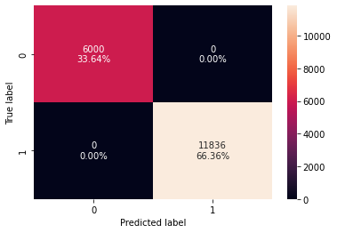

```python
confusion_matrix_sklearn(dtree, X_train, y_train)
```

```python
dtree.score(X_train, y_train)
```

```
1.0
```

- 0 errors on the training set, each sample has been classified correctly.
- Model has performed very well on the training set.

#### Checking model performance on test set

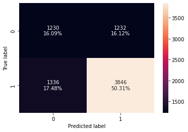

```python
confusion_matrix_sklearn(dtree, X_test, y_test)
```

```python
decision_tree_perf_test = model_performance_classification_sklearn(
    dtree, X_test, y_test)
decision_tree_perf_test
```

|  | Accuracy | Recall | Precision | F1 |
| --- | --- | --- | --- | --- |
| 0 | 0.66405 | 0.742184 | 0.757385 | 0.749708 |

- The decision tree model is overfitting the data as expected and not able to generalize well on the test set. Pruning is recomended.

### Hyperparameter Tuning - Decision Tree

```python
dtree_estimator = DecisionTreeClassifier(
    class_weight={0: 0.35, 1: 0.65}, random_state=1
)


parameters = {
    "max_depth": np.arange(2, 10),
    "min_samples_leaf": [5, 7, 10, 15],
    "max_leaf_nodes": [2, 3, 5, 10, 15],
    "min_impurity_decrease": [0.0001, 0.001, 0.01, 0.1],
}


scorer = metrics.make_scorer(metrics.recall_score)


grid_obj = GridSearchCV(dtree_estimator, parameters, scoring=scorer, n_jobs=-1)
grid_obj = grid_obj.fit(X_train, y_train)


dtree_estimator = grid_obj.best_estimator_


dtree_estimator.fit(X_train, y_train)
```

```
DecisionTreeClassifier(class_weight={0: 0.35, 1: 0.65}, max_depth=2,
                       max_leaf_nodes=2, min_impurity_decrease=0.1,
                       min_samples_leaf=5, random_state=1)
```

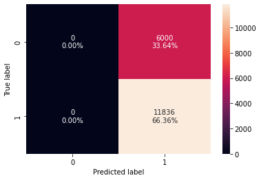

```python
confusion_matrix_sklearn(dtree_estimator, X_train, y_train)
```

```python
dtree_estimator_model_train_perf = model_performance_classification_sklearn(
    dtree_estimator, X_train, y_train
)
dtree_estimator_model_train_perf
```

|  | Accuracy | Recall | Precision | F1 |
| --- | --- | --- | --- | --- |
| 0 | 0.663602 | 1.0 | 0.663602 | 0.797789 |

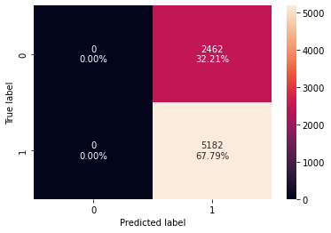

```python
confusion_matrix_sklearn(dtree_estimator, X_test, y_test)
```

```python
dtree_estimator_model_test_perf = model_performance_classification_sklearn(
    dtree_estimator, X_test, y_test)
dtree_estimator_model_test_perf
```

|  | Accuracy | Recall | Precision | F1 |
| --- | --- | --- | --- | --- |
| 0 | 0.677917 | 1.0 | 0.677917 | 0.808046 |

- The decision tree model has a very high recall but, the precision is quite less.
- The performance of the model after hyperparameter tuning has become generalized.
- Getting an F1 score of 0.79 and 0.80 on the training and test set, respectively.
- Building some ensemble models and see if the metrics improve.

## Bagging - Model Building and Hyperparameter Tuning

### Bagging Classifier

```python
bagging = BaggingClassifier(random_state=1)
bagging.fit(X_train, y_train)
```

```
BaggingClassifier(random_state=1)
```

#### Checking model performance on training set

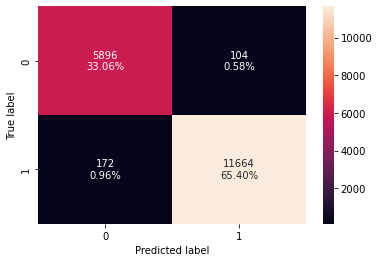

```python
confusion_matrix_sklearn(bagging, X_train, y_train)
```

```python
bagging_model_train_perf = model_performance_classification_sklearn(
    bagging, X_train, y_train
)
bagging_model_train_perf
```

|  | Accuracy | Recall | Precision | F1 |
| --- | --- | --- | --- | --- |
| 0 | 0.984526 | 0.985468 | 0.991162 | 0.988307 |

#### Checking model performance on test set

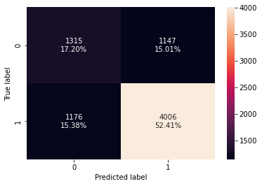

```python
confusion_matrix_sklearn(bagging, X_test, y_test)
```

```python
bagging_model_test_perf = model_performance_classification_sklearn(
    bagging, X_test, y_test
)
bagging_model_train_perf
```

[output not shown]

|  | Accuracy | Recall | Precision | F1 |
| --- | --- | --- | --- | --- |
| 0 | 0.984526 | 0.985468 | 0.991162 | 0.988307 |

- The bagging classifier is overfitting on the training set like the decision tree model.
- Reducing overfitting and improve the performance by hyperparameter tuning.

### Hyperparameter Tuning - Bagging Classifier

```python
bagging_estimator_tuned = BaggingClassifier(random_state=1)


parameters = {
    "max_samples": [0.7, 0.9],
    "max_features": [0.7, 0.9],
    "n_estimators": np.arange(90, 120, 10),}


acc_scorer = metrics.make_scorer(metrics.f1_score)


grid_obj = GridSearchCV(bagging_estimator_tuned, parameters, scoring=acc_scorer, cv=5)
grid_obj = grid_obj.fit(X_train, y_train)


bagging_estimator_tuned = grid_obj.best_estimator_


bagging_estimator_tuned.fit(X_train, y_train)
```

```
BaggingClassifier(max_features=0.7, max_samples=0.7, n_estimators=110,
                  random_state=1)
```

#### Checking model performance on training set

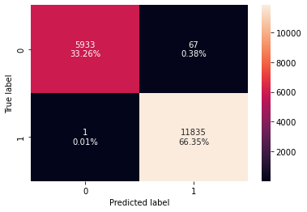

```python
confusion_matrix_sklearn(bagging_estimator_tuned, X_train, y_train)
```

```python
bagging_estimator_tuned_model_train_perf = model_performance_classification_sklearn(bagging_estimator_tuned, X_train, y_train)
bagging_estimator_tuned_model_train_perf
```

|  | Accuracy | Recall | Precision | F1 |
| --- | --- | --- | --- | --- |
| 0 | 0.996187 | 0.999916 | 0.994371 | 0.997135 |

#### Checking model performance on test set

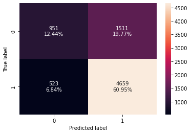

```python
confusion_matrix_sklearn(bagging_estimator_tuned, X_test, y_test)
```

```python
bagging_estimator_tuned_model_test_perf = model_performance_classification_sklearn(bagging_estimator_tuned, X_test, y_test)
bagging_estimator_tuned_model_test_perf
```

|  | Accuracy | Recall | Precision | F1 |
| --- | --- | --- | --- | --- |
| 0 | 0.733909 | 0.899074 | 0.755105 | 0.820825 |

- After tuning the hyperparameters the bagging classifier is still overfitting.
- However, there's a big difference in the training and the test recall.

### Random Forest

```python
rf_estimator = RandomForestClassifier(random_state=1, class_weight="balanced")
rf_estimator.fit(X_train, y_train)
```

```
RandomForestClassifier(class_weight='balanced', random_state=1)
```

#### Checking model performance on training set

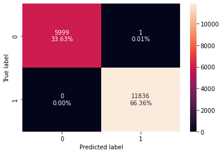

```python
confusion_matrix_sklearn(rf_estimator, X_train, y_train)
```

```python
rf_estimator_model_train_perf = model_performance_classification_sklearn(
    rf_estimator, X_train, y_train
)
rf_estimator_model_train_perf
```

|  | Accuracy | Recall | Precision | F1 |
| --- | --- | --- | --- | --- |
| 0 | 0.999944 | 1.0 | 0.999916 | 0.999958 |

#### Checking model performance on test set

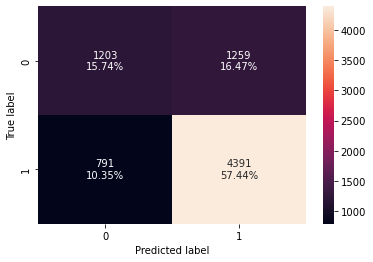

```python
confusion_matrix_sklearn(rf_estimator, X_test, y_test)
```

```python
rf_estimator_model_test_perf = model_performance_classification_sklearn(
    rf_estimator, X_test, y_test
)
rf_estimator_model_test_perf
```

|  | Accuracy | Recall | Precision | F1 |
| --- | --- | --- | --- | --- |
| 0 | 0.731816 | 0.847356 | 0.777168 | 0.810746 |

- With default parameters, random forest is overfitting the training data.
- Reducing overfitting and improving recall by hyperparameter tuning.